# Comparative Anti-Trypanosomal Activity of Azadirachta indica and Moringa oleifera against Trypanosoma congolense and T. evansi — Statistical Report

## 1 Abstract

Methanolic extracts of *Azadirachta indica* and *Moringa oleifera* (leaves, stem bark, roots, seeds) were tested against *Trypanosoma congolense* and *T. evansi* in motility assays and in albino mice (N = 16 plant × part × parasite blocks; group means of n = 3 mice). Both parasites responded in a monotonic, concentration-dependent manner. *T. evansi* responded significantly (parasitaemia Friedman p = 0.006; 100, 10 and 0.5 mg/ml each superior to control, Holm 0.039); *T. congolense* responded suggestively (Friedman p = 0.074; 100 mg/ml Holm 0.071). At 100 mg/ml, mean peak parasitaemia was zero with no mortality in either parasite, against peak LEV 5 with universal mortality in Negative Controls. The two plants were indistinguishable (paired p = 1.0; HL 0.3, 95% CI −14.7 to 20.5). Inference is block-level and rank-based throughout, and all headline claims withstood leave-one-block-out sensitivity analysis.

## 2 1. Aim and structure of this report

The aim of the study is to compare the anti-trypanosomal activity of methanolic extracts of *A. indica* and *M. oleifera* (leaves, stem bark, roots, seeds) against *T. congolense* and *T. evansi* (thesis Section 1.8.1). This report presents the statistical analysis for specific objectives ii–v (Section 1.8.2): phytochemical characterisation (Section 5.2), the in-vitro motility assay (Section 5.3), in-vivo infectivity (Section 5.4) and the superiority assessment (Section 5.5), followed by diagnostics (Section 6), an integrative discussion against the recent literature (Section 7) and limitations (Section 8). Objective i (extraction) is a laboratory procedure without recorded replicates and carries no statistical component (Section 5.1).

## 3 2. Design and analytical approach

The source data are group means of three mice per group. Consequently, each treatment group within a plant × part × parasite block is a single observation, and the block (N = 16; eight per plant and per parasite) is the unit of analysis. Plant effects are estimated from eight part × parasite pairs; parasite effects from eight plant × part pairs. Controls are reported as labelled in the source, their identities and doses being unstated, so the Positive Control functions as an assay-validity reference rather than a comparator. With at most eight pairs per test, the design has low power by construction; effect sizes with confidence intervals are therefore reported throughout and p-values treated as supplementary.

## 4 3. Endpoints

The primary parasitaemia endpoint is the death-censored AUC (trapezoidal sum over observed days), interpreted strictly alongside mortality; peak LEV, clearance day and day-40 status are supporting. Day-40 LEV alone is uninformative (no group positive at day 40 against ~30% positivity at days 9–14). Motility is summarised as time-to-immobilisation, t120 motility and mean proportion motile (source key: `+ Active`, `− No motility`; the two `+-` cells set to NA). Weight and PCV enter as Post-minus-Pre differences with literature-based anaemia and weight-loss flags. LEV readings above the 0–5 scale (42 cells) were capped at 5 with raw values preserved and flagged; missing in-vivo values were taken as deaths (an adopted convention, never imputed).

## 5 4. Statistical methods

All inference is rank-based: Friedman tests blocked by block for ordered dose trends with pooled Spearman correlations on log10 dose, and paired Wilcoxon signed-rank tests for dose-versus-control post-hoc families (Holm-adjusted per parasite) and for plant and parasite contrasts, each accompanied by the matched-pairs rank-biserial effect (|r| ≥ 0.11/0.28/0.43 as small/medium/ large) and the Hodges–Lehmann median difference with 95% confidence interval. Exact p-values are used wherever the data permit; where tied ranks or zero differences occur, the continuity-corrected normal approximation is substituted and the substitution recorded per contrast (Section 6). Per-block trend tests at n = 1 lack power, so only the blocked tests are inferential. Computations are in `analysis/R/02_analysis.R`; no machine learning was used. Analysis variables are specified exactly as named in code and data files in Table 1; Results and Discussion use proper display names.

Table 1: Analysis variables as specified in code and data files.

| Variable | Description | File |
| --- | --- | --- |
| `auc` | Death-censored trapezoidal AUC over observed days | `endpoints_parasitemia.csv` |
| `peak_lev` | Maximum LEV within group | `endpoints_parasitemia.csv` |
| `clear_day` | Last day with LEV > 0 | `endpoints_parasitemia.csv` |
| `day40_lev` | LEV at day 40 (0 or missing) | `endpoints_parasitemia.csv` |
| `tti` | First time with motility 0 | `endpoints_motility.csv` |
| `mot120` | Motility at 120 min | `endpoints_motility.csv` |
| `mean_motile` | Mean proportion motile over 0-120 min | `endpoints_motility.csv` |
| `delta` | Post-Infection minus Pre-Infection (weight, PCV) | `endpoints_weight.csv`, `endpoints_pcv.csv` |
| `present` | Phytochemical presence (TRUE/FALSE) | `phytochemical.csv` |
| `concentration_mgml` | Dose in mg/ml (NA for controls) | `motility.csv`, `parasitemia.csv` |

## 6 5.1. Objective i — methanolic extraction

No yields or replicates were recorded for the extraction step, so objective i contributes no data to the analysis and is noted here only for completeness.

## 7 5.2. Objective ii — phytochemical contents

The screening panel resolved eight of twelve compound classes in at least one extract, distributed along a part axis rather than a plant axis. Leaves were the richest fraction in both species (6 of 12 classes each), stem bark and roots the sparsest (3–4), and seeds intermediate (4–5; Table 2, Figure 1). Saponins and carbohydrates were ubiquitous (8 of 8 combinations) while anthraquinones, phlobatannins, oxalates and phytates were uniformly absent, so neither group discriminates the plants; tannins showed the sharpest part pattern, present everywhere except seeds in both species (Figure 2). The few differentiating classes were part-specific rather than species-specific: steroids (only *A. indica* leaves and seeds), terpenoids (only *M. oleifera* stem bark), and alkaloids, flavonoids and glucosides in asymmetric but overlapping distributions — the two leaf profiles share six classes apiece with only the steroid/glucoside entries swapped. With eight combinations, these data admit description only; compound–efficacy overlays are tabulated without tests. The substantive point for Section 7 is the extent of chemical overlap between the species, which leaves little phytochemical basis for expecting divergent efficacy.

Table 2: Phytochemical richness per plant and part (descriptive).

| Plant | Part | n Present | n Absent |
| --- | --- | --- | --- |
| A. indica | leaves | 6 | 6 |
| A. indica | roots | 3 | 9 |
| A. indica | seeds | 5 | 7 |
| A. indica | stem bark | 3 | 9 |
| M. oleifera | leaves | 6 | 6 |
| M. oleifera | roots | 4 | 8 |
| M. oleifera | seeds | 4 | 8 |
| M. oleifera | stem bark | 4 | 8 |

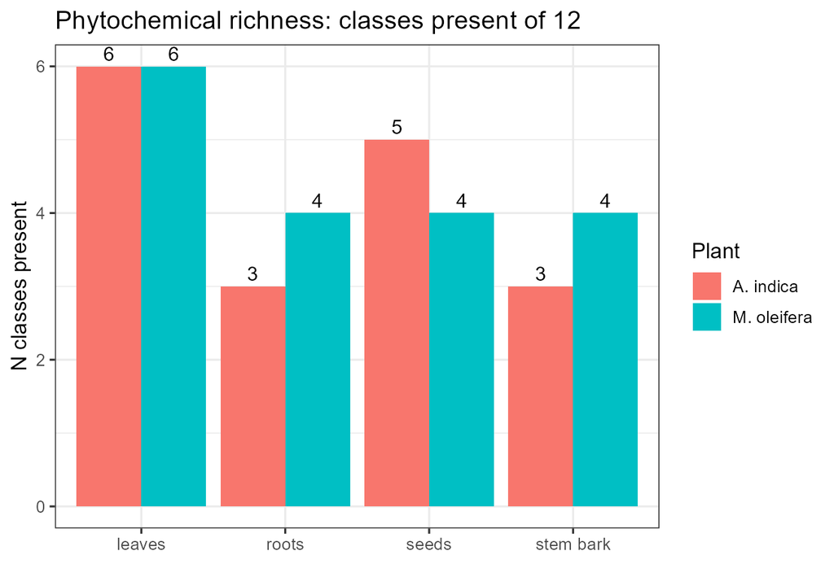

Figure 1: Richness: classes present of 12

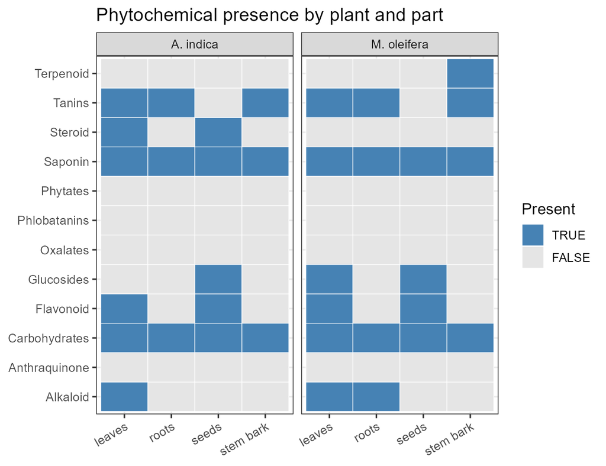

Figure 2: Phytochemical presence by plant and part

## 8 5.3. Objective iii — in-vitro motility

Table 3: TTI and t120 summaries per dose (medians; censored groups never immobilise).

| Parasite | Group | n Groups | Median TTI | n Never Immobilised | Mean T120 |
| --- | --- | --- | --- | --- | --- |
| T. congolense | 100mg/ml | 8 | 15.0 | 0 | 0.000 |
| T. congolense | 10mg/ml | 8 | 30.0 | 0 | 0.000 |
| T. congolense | 0.5mg/ml | 8 | 52.5 | 2 | 0.250 |
| T. congolense | 0.01mg/ml | 8 | 60.0 | 3 | 0.375 |
| T. congolense | 0.005mg/ml | 8 | 90.0 | 3 | 0.375 |
| T. congolense | Negative Control | 8 | 112.5 | 6 | 0.667 |
| T. congolense | Positive Control | 8 | 15.0 | 0 | 0.000 |
| T. evansi | 100mg/ml | 8 | 15.0 | 0 | 0.000 |
| T. evansi | 10mg/ml | 8 | 22.5 | 0 | 0.000 |
| T. evansi | 0.5mg/ml | 8 | 45.0 | 1 | 0.125 |
| T. evansi | 0.01mg/ml | 8 | 75.0 | 3 | 0.375 |
| T. evansi | 0.005mg/ml | 8 | 105.0 | 4 | 0.500 |
| T. evansi | Negative Control | 8 | NA | 8 | 1.000 |
| T. evansi | Positive Control | 8 | 15.0 | 0 | 0.000 |

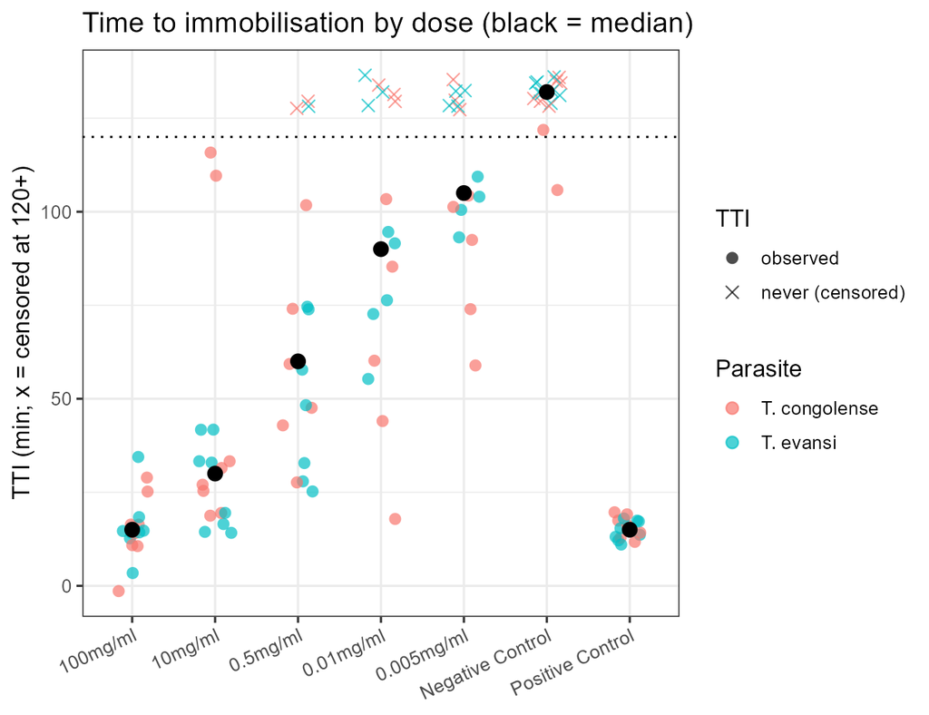

Figure 3: Time to immobilisation by dose (black = median; x = censored)

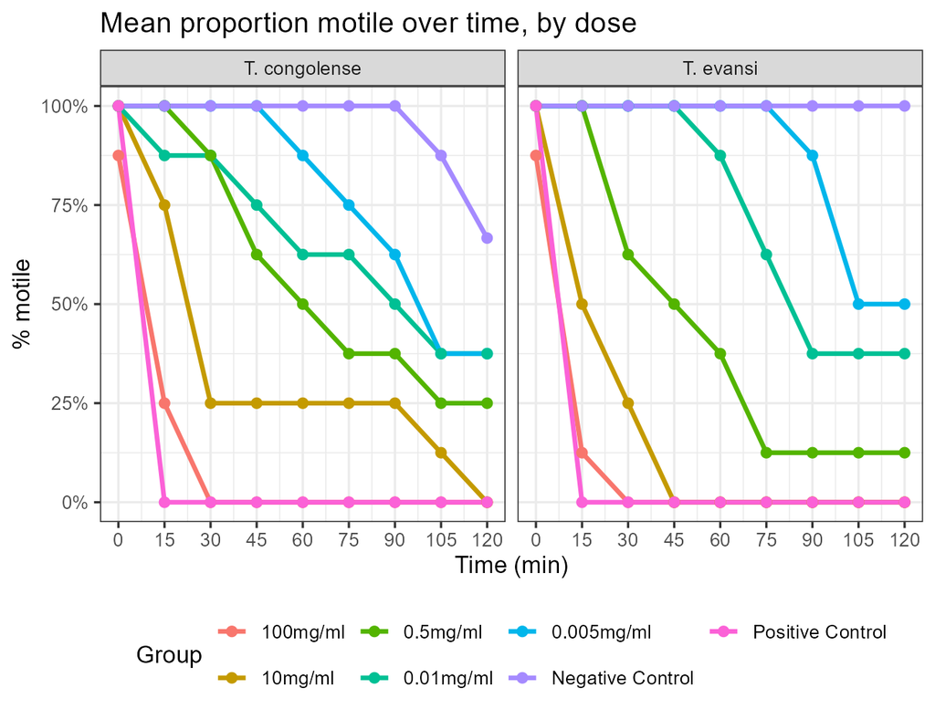

Figure 4: Mean proportion motile over time, by dose

Table 4: Motility dose-response on mean proportion motile (Friedman blocked by block; Spearman on log10 dose).

| Parasite | n Blocks | Friedman Q | Friedman p | Spearman Rho Pooled | Spearman p |
| --- | --- | --- | --- | --- | --- |
| T. congolense | 8 | 27.75 | 0 | -0.698 | 0 |
| T. evansi | 8 | 30.32 | 0 | -0.883 | 0 |

Table 5: Post-hoc motility contrasts vs Negative Control (paired Wilcoxon; Holm per parasite).

| Dose | Parasite | n | W | p | p (Holm) | HL [95% CI] | r |
| --- | --- | --- | --- | --- | --- | --- | --- |
| 100mg/ml vs NC | T. congolense | 8 | 0.0 | 0.0131 | 0.0655 | -0.83 [-0.94, -0.72] | -1.0000 |
| 10mg/ml vs NC | T. congolense | 8 | 0.0 | 0.0213 | 0.0852 | -0.78 [-0.83, -0.44] | -1.0000 |
| 0.5mg/ml vs NC | T. congolense | 8 | 0.0 | 0.0579 | 0.1737 | -0.61 [-0.78, -0.44] | -1.0000 |
| 0.01mg/ml vs NC | T. congolense | 8 | 1.5 | 0.0739 | 0.1737 | -0.39 [-0.67, -0.06] | -0.6667 |
| 0.005mg/ml vs NC | T. congolense | 8 | 2.5 | 0.1058 | 0.1737 | -0.22 [-0.44, 0.00] | -0.6667 |
| 100mg/ml vs NC | T. evansi | 8 | 0.0 | 0.0104 | 0.0519 | -0.89 [-0.94, -0.83] | -1.0000 |
| 10mg/ml vs NC | T. evansi | 8 | 0.0 | 0.0129 | 0.0519 | -0.79 [-0.89, -0.72] | -1.0000 |
| 0.5mg/ml vs NC | T. evansi | 8 | 0.0 | 0.0213 | 0.0639 | -0.61 [-0.78, -0.50] | -1.0000 |
| 0.01mg/ml vs NC | T. evansi | 8 | 0.0 | 0.0568 | 0.1135 | -0.44 [-0.50, -0.33] | -1.0000 |
| 0.005mg/ml vs NC | T. evansi | 8 | 0.0 | 0.0890 | 0.1135 | -0.22 [-0.22, -0.22] | -1.0000 |

## 9 5.4. Objective iv — in-vivo infectivity

### 9.1 Parasitaemia

The in-vivo gradient reproduced the dish. Mean peak parasitaemia declined monotonically with dose to exactly zero at 100 mg/ml in both parasites with no deaths, against peak LEV 5 with universal mortality in the Negative Controls (Table 6; Figure 5); mortality, clearance time and day-40 clearance all tracked the same ordering (Figure 6), and trajectories peaked near days 9–14 before resolving in survivors (Figure 8). On cumulative burden the *T. evansi* trend was significant (Table 7: Friedman Q = 14.51, p = 0.006, ρ = −0.51) with 100, 10 and 0.5 mg/ml each superior to control in all eight blocks (W = 0, exact p = 0.008, Holm 0.039; HL ≈ −50/−50/−44 AUC-days), while 0.01 and 0.005 mg/ml lost significance on correction (Holm 0.078) despite strongly negative estimates. *T. congolense* showed the same direction with weaker evidence (Friedman p = 0.074; 100 mg/ml Holm 0.071, HL −29.9 [−41.0, −20.9]; lower doses Holm ≥ 0.32; Table 8, Figure 7). Overall burdens did not differ between parasites (paired p = 0.46, HL 6.0 [−10.7, 21.1]; Table 10): the species differ in dose sensitivity, not in the burden the model produces.

Table 6: Peak, clearance and mortality per dose (means/medians over 8 blocks).

| Parasite | Group | n Groups | Mean Peak | Median Clear Day | Pct Died | Pct Day40 Zero |
| --- | --- | --- | --- | --- | --- | --- |
| T. congolense | 100mg/ml | 8 | 0.000 | NA | 0.0 | 100.0 |
| T. congolense | 10mg/ml | 8 | 1.875 | 24.0 | 37.5 | 62.5 |
| T. congolense | 0.5mg/ml | 8 | 2.779 | 17.0 | 62.5 | 37.5 |
| T. congolense | 0.01mg/ml | 8 | 3.125 | 15.0 | 62.5 | 37.5 |
| T. congolense | 0.005mg/ml | 8 | 3.192 | 16.5 | 75.0 | 25.0 |
| T. congolense | Negative Control | 8 | 5.000 | 11.5 | 100.0 | 0.0 |
| T. congolense | Positive Control | 8 | 0.000 | NA | 0.0 | 100.0 |
| T. evansi | 100mg/ml | 8 | 0.000 | NA | 0.0 | 100.0 |
| T. evansi | 10mg/ml | 8 | 0.000 | NA | 0.0 | 100.0 |
| T. evansi | 0.5mg/ml | 8 | 0.625 | 17.0 | 12.5 | 87.5 |
| T. evansi | 0.01mg/ml | 8 | 1.926 | 23.5 | 50.0 | 50.0 |
| T. evansi | 0.005mg/ml | 8 | 2.084 | 22.5 | 50.0 | 50.0 |
| T. evansi | Negative Control | 8 | 5.000 | 19.5 | 100.0 | 0.0 |
| T. evansi | Positive Control | 8 | 0.000 | NA | 0.0 | 100.0 |

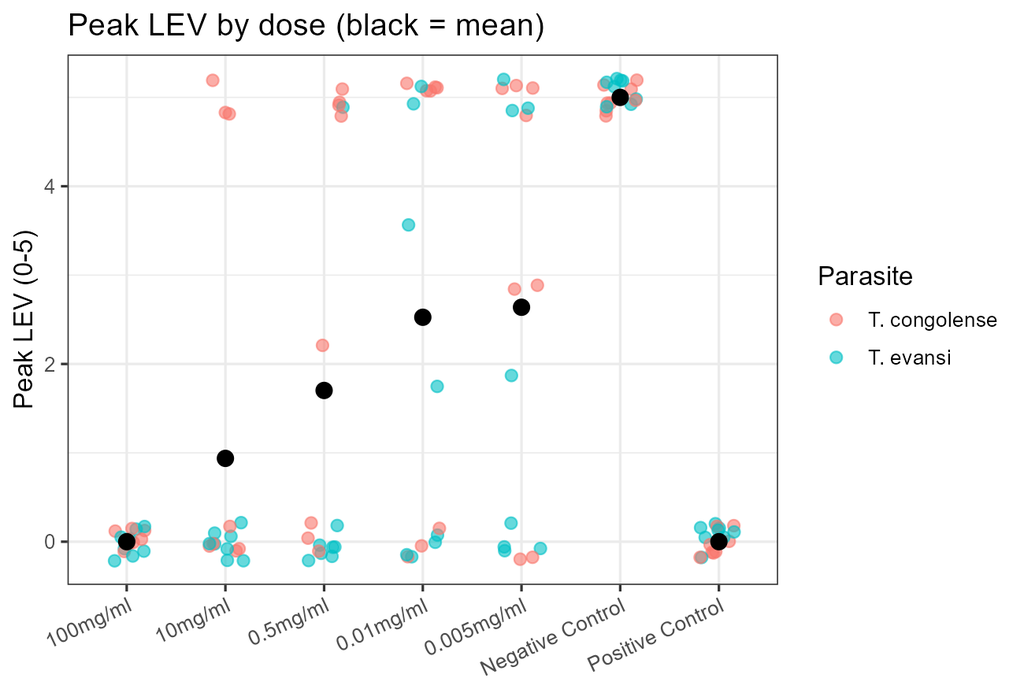

Figure 5: Peak LEV by dose (black = mean)

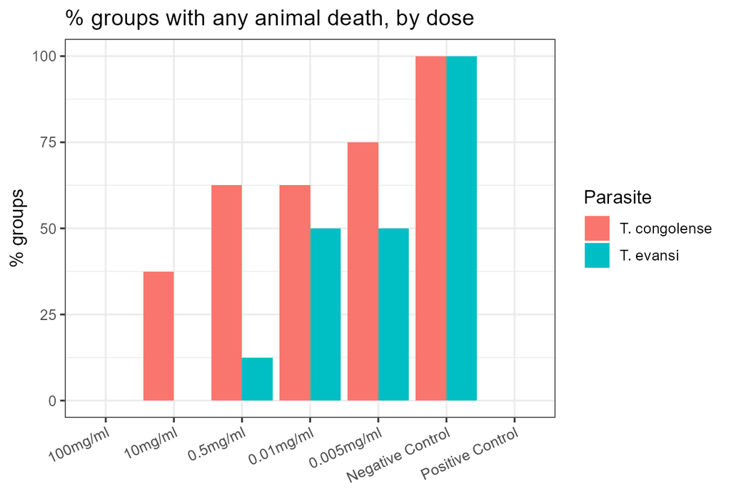

Figure 6: Groups with any death, by dose

Table 7: Parasitaemia dose-response on AUC (Friedman blocked by block; Spearman on log10 dose).

| Parasite | n Blocks | Friedman Q | Friedman Df | Friedman p | Spearman Rho Pooled | Spearman p | Mean Rho Perblock |
| --- | --- | --- | --- | --- | --- | --- | --- |
| T. congolense | 8 | 8.519 | 4 | 0.074 | -0.419 | 0.007 | -0.458 |
| T. evansi | 8 | 14.507 | 4 | 0.006 | -0.509 | 0.001 | -0.861 |

Table 8: Post-hoc parasitaemia contrasts vs Negative Control on AUC (paired Wilcoxon; Holm per parasite).

| Dose | Parasite | n | W | p | p (Holm) | HL [95% CI] | r |
| --- | --- | --- | --- | --- | --- | --- | --- |
| 100mg/ml vs NC | T. congolense | 8 | 0 | 0.0141 | 0.0707 | -29.89 [-40.97, -20.92] | -1.00 |
| 10mg/ml vs NC | T. congolense | 8 | 5 | 0.0797 | 0.3188 | -13.25 [-29.10, 2.54] | -0.50 |
| 0.5mg/ml vs NC | T. congolense | 8 | 7 | 0.1410 | 0.4230 | -11.93 [-24.14, 10.97] | -0.75 |
| 0.01mg/ml vs NC | T. congolense | 8 | 11 | 0.3621 | 0.7243 | -7.39 [-24.14, 12.96] | -0.50 |
| 0.005mg/ml vs NC | T. congolense | 8 | 15 | 0.7260 | 0.7260 | -6.59 [-19.57, 10.76] | -0.25 |
| 100mg/ml vs NC | T. evansi | 8 | 0 | 0.0078 | 0.0391 | -50.30 [-74.60, -29.21] | -1.00 |
| 10mg/ml vs NC | T. evansi | 8 | 0 | 0.0078 | 0.0391 | -50.30 [-74.60, -29.21] | -1.00 |
| 0.5mg/ml vs NC | T. evansi | 8 | 0 | 0.0078 | 0.0391 | -44.13 [-74.60, -29.21] | -1.00 |
| 0.01mg/ml vs NC | T. evansi | 8 | 5 | 0.0781 | 0.0781 | -31.72 [-65.63, 2.18] | -0.75 |
| 0.005mg/ml vs NC | T. evansi | 8 | 3 | 0.0391 | 0.0781 | -34.24 [-68.51, -9.40] | -0.50 |

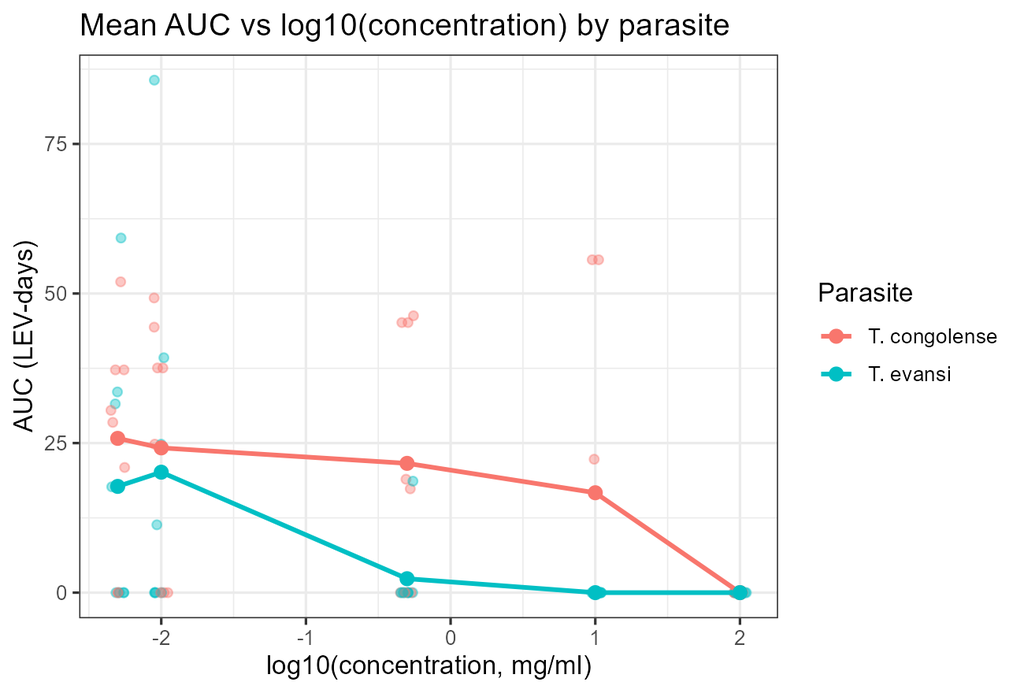

Figure 7: Mean AUC vs log10(concentration)

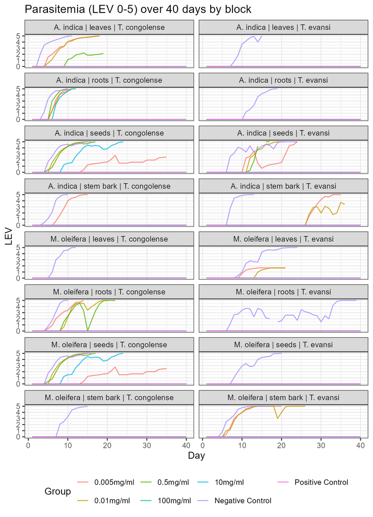

Figure 8: Parasitaemia trajectories by block

### 9.2 Body weight and PCV

Table 9: Toxicity/anaemia flag counts (descriptive).

| Dataset | Plant | Parasite | Flag | n Groups |
| --- | --- | --- | --- | --- |
| pcv | A. indica | T. congolense | anemia | 5 |
| pcv | A. indica | T. congolense | missing (died) | 7 |
| pcv | A. indica | T. evansi | missing (died) | 1 |
| pcv | A. indica | T. evansi | severe anemia | 2 |
| pcv | M. oleifera | T. congolense | anemia | 4 |
| pcv | M. oleifera | T. congolense | missing (died) | 3 |
| pcv | M. oleifera | T. evansi | anemia | 2 |
| weight | A. indica | T. congolense | missing (died) | 7 |
| weight | A. indica | T. congolense | severe weight loss (>=20%) | 4 |
| weight | A. indica | T. congolense | toxicity signal (>=10% loss) | 4 |
| weight | A. indica | T. evansi | missing (died) | 1 |
| weight | A. indica | T. evansi | severe weight loss (>=20%) | 1 |
| weight | A. indica | T. evansi | toxicity signal (>=10% loss) | 2 |
| weight | M. oleifera | T. congolense | missing (died) | 3 |
| weight | M. oleifera | T. congolense | severe weight loss (>=20%) | 2 |
| weight | M. oleifera | T. congolense | toxicity signal (>=10% loss) | 4 |

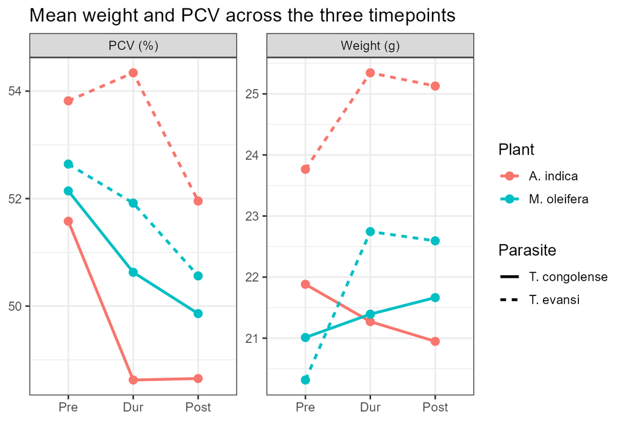

Figure 9: Mean weight and PCV across timepoints

Table 10: Parasite, weight and PCV contrasts (paired Wilcoxon; 8 pairs each).

| Endpoint | Contrast | n | W | p | HL [95% CI] | r |
| --- | --- | --- | --- | --- | --- | --- |
| AUC | T. congolense vs T. evansi | 8 | 24 | 0.4609 | 5.95 [-10.69, 21.10] | 0.25 |
| Weight delta | weight delta: plant | 8 | 10 | 0.3125 | -0.81 [-2.29, 0.44] | 0.00 |
| Weight delta | weight delta: parasite | 8 | 7 | 0.1484 | -1.34 [-3.90, 0.29] | -0.50 |
| PCV delta | pcv delta: plant | 8 | 21 | 0.7422 | 0.48 [-3.70, 4.38] | 0.25 |
| PCV delta | pcv delta: parasite | 8 | 19 | 0.9453 | 0.40 [-3.62, 3.48] | 0.00 |

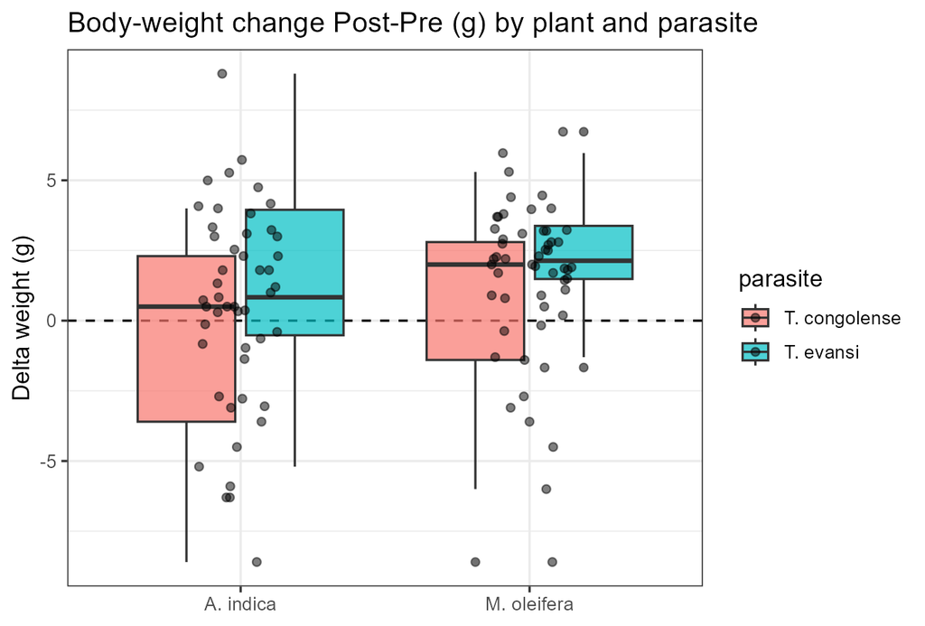

Figure 10: Body-weight change Post−Pre (g)

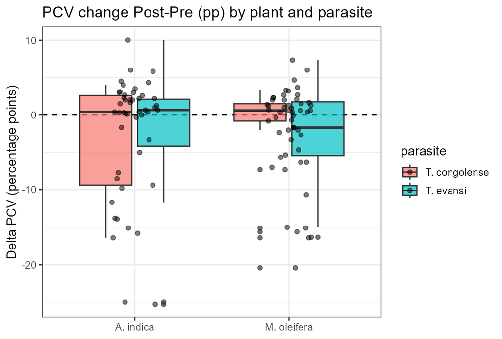

Figure 11: PCV change Post−Pre (pp)

## 10 5.5. Objective v — comparative superiority

The eight paired differences span zero with no structure: three favour *M. oleifera* (to −21.5 AUC-days), four favour *A. indica* (to +18.1), one is an exact tie, and neither part nor parasite predicts the sign (Figure 12; Figure 13). The paired test returns the null almost exactly (W = 14, exact p = 1.0; HL 0.3, 95% CI −14.7 to 20.5; rank-biserial −0.14), and the motility cross-check concurs (p = 0.15; Table 11). Because the interval covers meaningful effects in both directions, the data neither establish nor exclude a modest plant difference — but as a superiority claim for either agent, the answer is negative, and it is insensitive to any single block (Section 6).

Table 11: Plant superiority contrasts (paired Wilcoxon; 8 pairs each).

| Endpoint | Contrast | n | W | p | HL [95% CI] | r |
| --- | --- | --- | --- | --- | --- | --- |
| AUC | A. indica vs M. oleifera | 8 | 14 | 1.0000 | 0.30 [-14.73, 20.54] | -0.1429 |
| Motility | A. indica vs M. oleifera | 8 | 29 | 0.1484 | 0.11 [-0.08, 0.24] | 0.2500 |

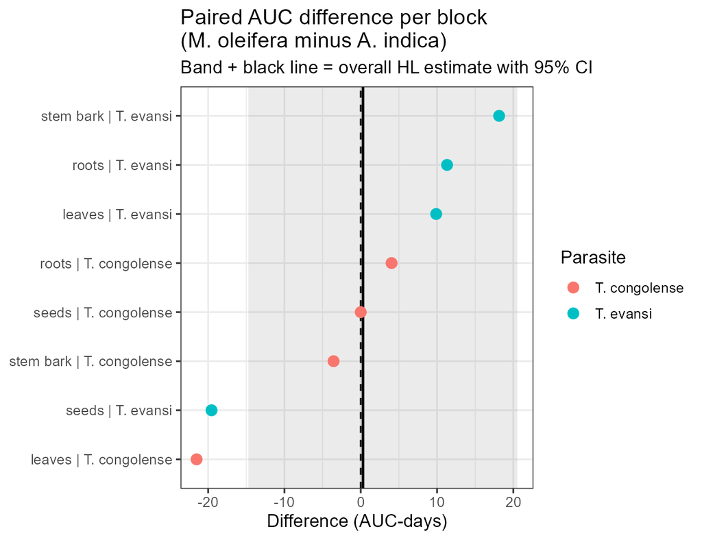

Figure 12: Paired AUC difference per block with overall HL estimate

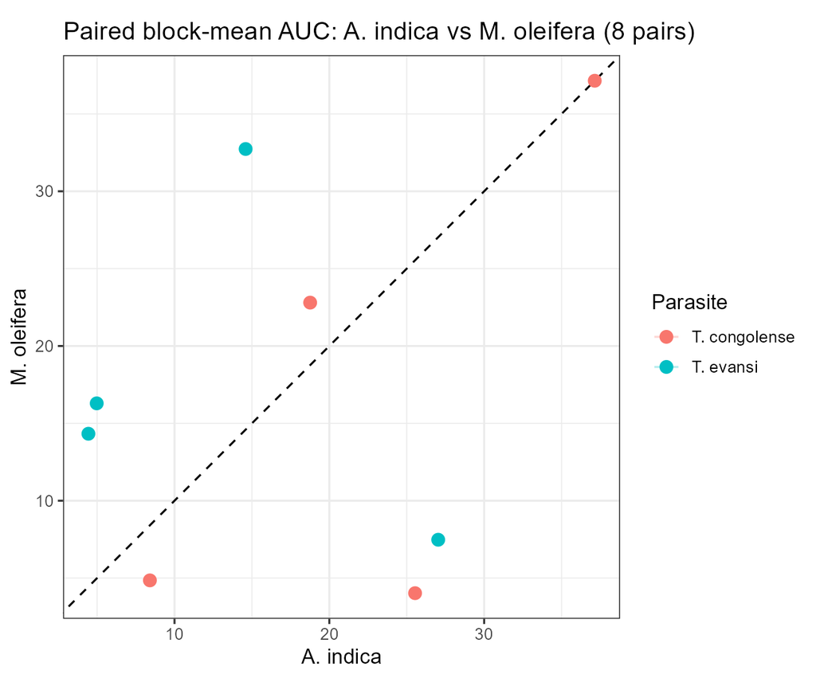

Figure 13: Paired block-mean AUC scatter

## 11 6. Diagnostics, sensitivity and refits

Contrasts with tied ranks or zero differences report `n_nonzero`, `n_ties` and the p-value method used (exact only when clean; continuity-corrected normal approximation otherwise); refitting on this basis left no conclusion changed. Paired differences were inspected for the symmetry the signed-rank test assumes (Figure 14): *evansi* differences form a pure location shift, while the superiority differences are symmetric about zero, consistent with its null. Leave-one-block-out re-analysis (Table 12) found no conclusion dependent on any single block. Completeness is asserted structurally at build.

Table 12: Leave-one-block-out sensitivity (stable = no single block flips the conclusion).

| Contrast | Full p | LOO p Min | LOO p Max | LOO Significant | LOO Runs | Stable |
| --- | --- | --- | --- | --- | --- | --- |
| evansi 100mg vs NC | 0.008 | 0.016 | 0.016 | 8 | 8 | TRUE |
| evansi 10mg vs NC | 0.008 | 0.016 | 0.016 | 8 | 8 | TRUE |
| evansi 0.5mg vs NC | 0.008 | 0.016 | 0.016 | 8 | 8 | TRUE |
| congolense 100mg vs NC | 0.014 | 0.016 | 0.022 | 8 | 8 | TRUE |
| plant superiority | 1.000 | 0.529 | 1.000 | 0 | 8 | TRUE |

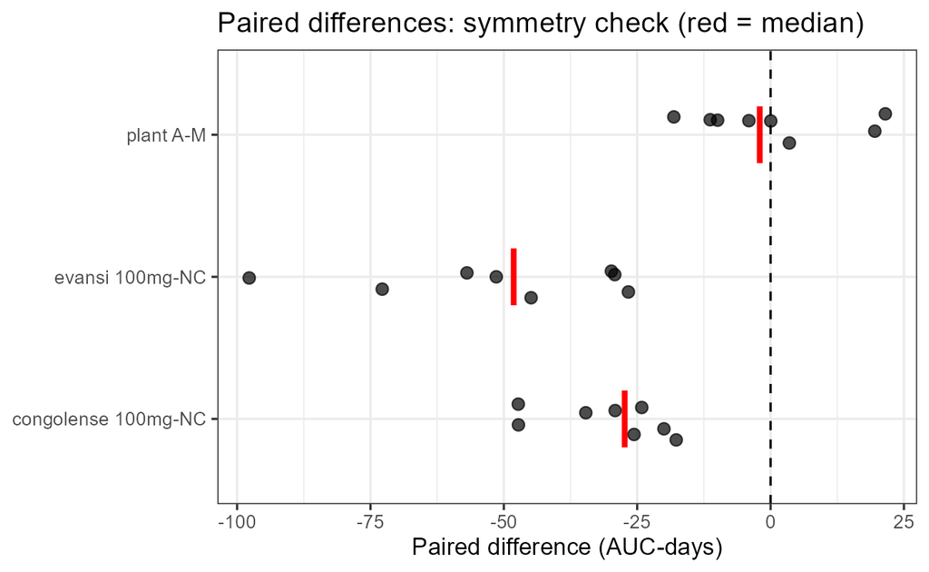

Figure 14: Paired differences: symmetry check (red = median)

## 12 7. Discussion

The three assay layers converge on one finding — both extracts are genuinely and dose-dependently trypanocidal — and each layer has a direct precedent in the recent literature. The in-vitro ordering (TTI of 15 minutes at the top dose lengthening monotonically to fully censored controls; Figure 3, Figure 4) sits squarely in the published range: *Acacia* stem-bark extracts immobilised *T. congolense* within 15 minutes at their top doses (Ogbole et al. 2021), *Ranunculus* extracts and anemonin within 5–30 minutes (Sirak et al. 2024), and *A. indica* fractions within the hour (Tauheed et al. 2021). Notably, the Ogbole design is a near twin of the present assay — identical +/− scoring over 0–120 minutes, the same threshold behaviour with top doses matching the Berenil control and the lowest dose equalling the negative control — so the threshold pattern here replicates an established signature rather than standing alone. One caveat travels with this literature and applies here: Sirak et al. showed that in-vitro immobilisation at low doses need not mean death, with parasites recovering infectivity. The present TTI gradient is therefore read as a kill proxy corroborated by the infectivity outcomes (peaks and mortality), not as proof of death at every dose.

In-vivo, the dose-dependent suppression of peaks and burden with zero mortality at the top dose matches the direction reported for *A. indica* stem bark (Wanzala et al. 2017; Mbaya et al. 2010), *A. indica* leaves (Okoh 2018; Ngure et al. 2009) and *M. oleifera* seed and leaves (Ujah et al. 2020; Datti et al. 2020), including their shared observation that crude extracts suppress rather than sterilise at lower doses. Two contrasts with that literature deserve emphasis. First, the effective threshold here — full suppression at the top in-vitro-style dose with *T. evansi* yielding from 0.5 mg/ml — is strong for crude methanolic extracts, most of which in the cited studies reduced but did not clear parasitaemia; whether that reflects genuine potency or the concentration-based (rather than mg/kg) dosing of this design is a question for the thesis methods, not this analysis. Second, Rabe et al. (2024) found ethanolic *A. indica* markedly superior to *M. oleifera* against a diminazene-resistant *T. brucei* strain, whereas the present comparison across four parts and two parasites finds no difference; the reconciliation is context — single leaf extracts against a resistant strain versus broad part × parasite panels — and it cautions against generalising either result beyond its design.

The phytochemical picture is consistent with the pharmacology literature without overreaching it. The classes present here — alkaloids, flavonoids, saponins and tannins — are precisely those repeatedly tied to trypanocidal activity (Ujah et al. 2020; Ogbole et al. 2021), and the part-axis variation (steroids only in *A. indica* leaves/seeds, terpenoids only in *M. oleifera* stem bark) offers natural fractionation targets. The mechanistic hypothesis with the most direct support is trypanosome alternative oxidase inhibition, for which *A. indica* fractions already show dose-dependent motility suppression coupled to enzyme inhibition (Tauheed et al. 2021); testing the present extracts in that assay would be the logical next step. The weight and PCV nulls diverge from studies reporting PCV recovery under treatment (Datti et al. 2020; Ujah et al. 2020; Tauheed et al. 2021), but those studies used animal-level data with identified controls and larger groups, whereas the present group-mean design with eight blocks cannot resolve modest haematological effects — absence of evidence here, not evidence of absence, and the flag clustering still independently ranks *T. congolense* the more pathogenic parasite, in line with the comparative literature. Methodologically, the Sirak-style ANOVA+Tukey pipeline used across much of this literature assumes normality and independence that group-mean, ordinal, repeated observations violate; the block-level rank analysis here answers the same questions without those assumptions, at the accepted cost of power. Taken together, the supported position is narrow and firm: both extracts are active in a dose-dependent manner with the top dose fully suppressive, *T. evansi* the more sensitive parasite, and neither plant demonstrably superior — pending animal-level confirmatory work with identified controls, a refined 0.5–10 mg/ml grid around the *congolense* threshold, and fractionation toward the compound level.

## 13 8. Limitations

Group means of three mice erase within-group variance, so inference rests on sixteen blocks; intervals are wide and description carries the weight. Control identities and doses are unknown, restricting the Positive Control to a validity reference. Death-censored AUC flatters early-death groups and is therefore always read with mortality. The NA-equals-death convention awaits confirmation against animal records. All results are exploratory, not confirmatory.

## 14 9. References

- Barrett, M.P. (2025) — on toxicity and resistance limits of current trypanocides; cited via Abdullahi et al. (2026).
- Abdullahi, R.I. et al. (2026). Phytochemical profiling and in-vitro antitrypanosomal efficacy of *Combretum glutinosum* leaf extract. *FJS*.
- Adams, L. et al. (2024). Antitrypanosomal activities of *Anopyxis klaineana* stem bark extracts. *Heliyon* 10: e28025.
- Cliff, N. (1993, 1996); Vargha, A. & Delaney, H.D. (2000). *J. Educ. Behav. Stat.* 25(2): 101–133.
- Conover, W.J. (1999). *Practical Nonparametric Statistics* (3rd ed.). Wiley.
- Datti, Y. et al. (2020). In-vivo antitrypanosomal activity of *Moringa oleifera* leaf extract in rats. *GSC Biol. Pharm. Sci.* 11(1): 12–17.
- Gitonga, P.K. et al. (2017). Differential virulence of *T. congolense* and *T. brucei* strains. *Onderstepoort J. Vet. Res.* 84(1): a1412.
- Mann, H.B. & Whitney, D.R. (1947). *Ann. Math. Statist.* 18(1): 50–60.
- Mbaya, A.W. et al. (2010). Toxicity and antitrypanosomal activity of *A. indica* stem bark. *J. Ethnopharmacol.* 128: 495–400.
- Naessens, J. et al. (2005). *Clin. Exp. Immunol.* 139: 449–456.
- Ngure, R.M. et al. (2009). Antitrypanosomal effects of neem extract on *T. brucei rhodesiense*-infected mice. *East. J. Med.* 14: 2–9.
- Noyes, H. et al. (2009). Mechanisms controlling anaemia in *T. congolense*-infected mice. *PLoS ONE* 4(4): e5170.
- Ogbole, E. et al. (2021). Anti-trypanosomal activity and phytochemical screening of selected *Acacia* species. *J. Chem. Soc. Nigeria* 46(2).
- Okoh, M.E. (2018). In-vivo anti-trypanosomal activity of aqueous *A. indica* leaves on *T. brucei brucei*-infected mice. *Int. J. Infect. Dis. Ther.* 3(1).
- Rabe, Y. et al. (2024). In-vitro study of *A. indica*, *M. oleifera* and *C.ymbopogon* leaf extracts against diminazene-resistant *T. brucei brucei*. *SAJOLS*.
- Sirak, B. et al. (2024). In-vitro and in-vivo antitrypanosomal activity of *Ranunculus multifidus* and anemonin against *T. congolense*. *BMC Vet. Res.* 20: 38 (article 03856).
- Spearman, C. (1904). *Am. J. Psychol.* 15(1): 72–85.
- Tauheed, A. et al. (2021). Partially purified *A. indica* leaf fractions inhibit trypanosome alternative oxidase. *PMC* 8217781.
- Ujah, F.O. et al. (2020). In-vitro and in-vivo effect of *M. oleifera* seed extract on *T. brucei* and *T. congolense* in rats. *Int. J. Green Herb. Chem.* 9(2).
- Wanzala, E.N. et al. (2017). In-vitro and in-vivo anti-trypanosomal activities of methanol extract of *A. indica* stem bark. *Afr. J. Trad. Complement. Altern. Med.* 14(6).
- Wilcoxon, F. (1945). *Biometrics* 1(1): 86–89.